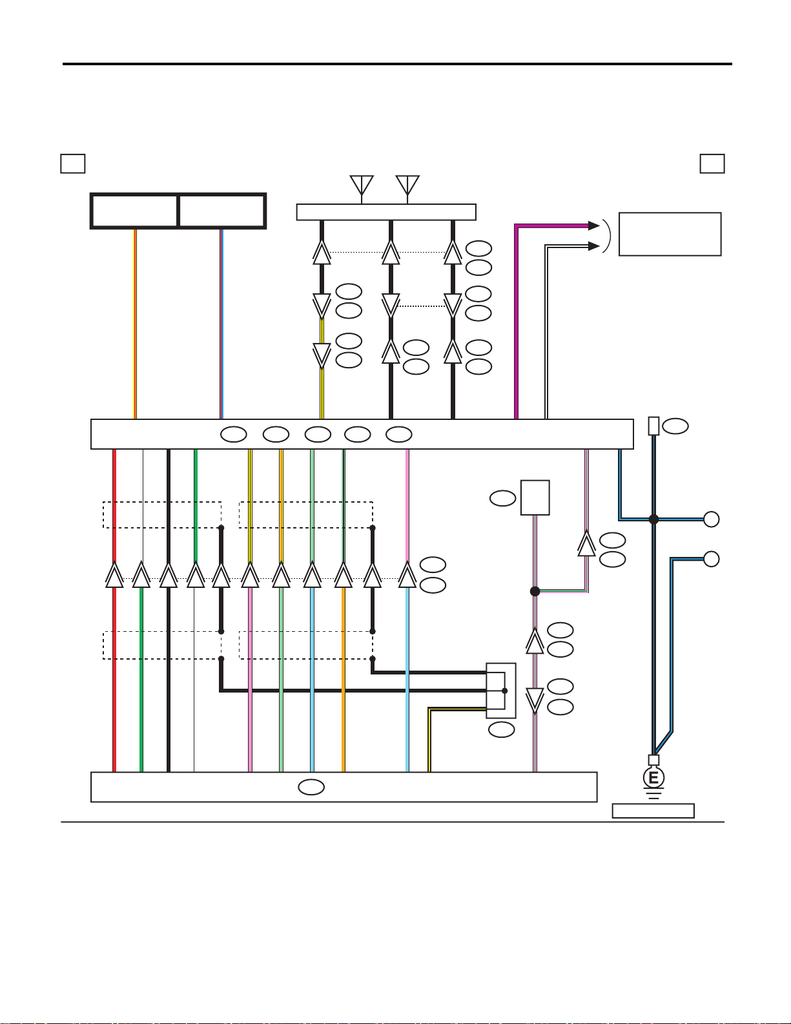

WI-303

Navigation System

WIRING SYSTEM

32.Navigation System

A: WIRING DIAGRAM

1. ENGINE TYPE FA

WI-44501

i131B

1a 1a

i50A

R386A

30A11 P/G P/G P/G

Y/R

L/R

Y/R

L/RA4

A3

V

V

A10

B/W

B/W

B5

B310

C:

i87

E:

AN1

F:

AN2

i29

B/L

B/L A7

1

B/L

A

B/L

B

C17

P/G

B/L

B/L

1

P/G

VDC CM

:

::

R14

J/C

1

1

1

A5

A4

A3

A2

A23

A22

A18

A17

A12

RA1

WA5

BA2

G

S

S

S

S

A6

Y/B B1

Y/R B3

LG B2

LG/B B6

P

R

G

B

W

P

LG

SB

O

SB

A6 B/Y

B/Y

S

S

A9

20

8

9

7

19

18

11

6

10

13

12

i195

R382

11

i230

23

R3

B99

R81

R82

19

AN15

AN11

AN6

AN4

AN5

AN3

AN8

R97

R167

i102

AN9

AN7

2

3

1

3

112

3

1

1

B552

Y/B

B

B

A8

E2

F1

B

B

B

B

B

B

Y/B

B

B

: TERMINAL No. OPTIONAL ARRANGEMENT

AUDIO AMPLIFIER

NAVIGATION UNIT

REF. TO GND [e]

FB-25

F/B FUSE NO. 24

(ACC)

FB-10

M/B FUSE NO. 8

(B)

REF. TO CLEARANCE

LIGHT & ILLUMINATION

LIGHT SYSTEM [1d] [2d]

AUDIO

BRACKET

GROUND

ANTENNA

SATELLITE

ANTENNA

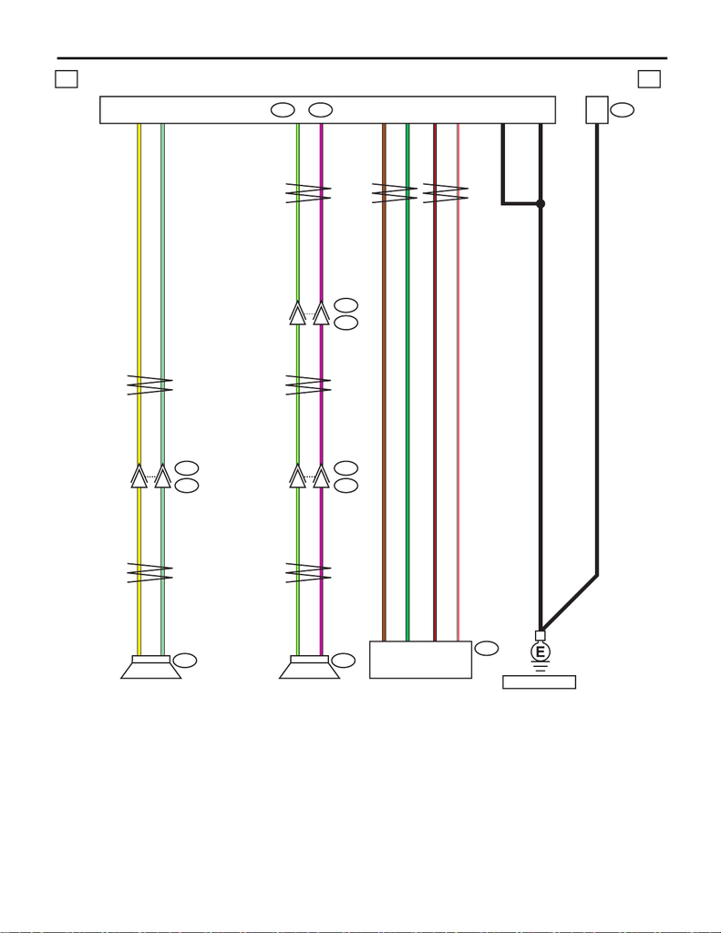

WI-304

Navigation System

WIRING SYSTEM

WI-44502

D23

1b 1b

D29

5

6

5

6

R317 R17C

B2

B61

2

G/Y

V

C5

C12

B

B

B

C6

C7

BB

1

BR

G

B8

B71

2

Y

LG

Y

LG

G/Y

V

G/Y

V

BR

G

C4

C10

3

4

1

2

B/R

W/R

B/R

W/R

Y

LG

G/Y

V

Y

LG

D28

R13

D22

R10

13

14

R81

R82

:R316B:

R117

REAR DOOR

SPEAKER RH (LOW)

REAR DOOR

SPEAKER LH (LOW)

AUDIO AMPLIFIER

AMPLIFIER

BRACKET GROUND

REF. TO GND [g]

WOOFER

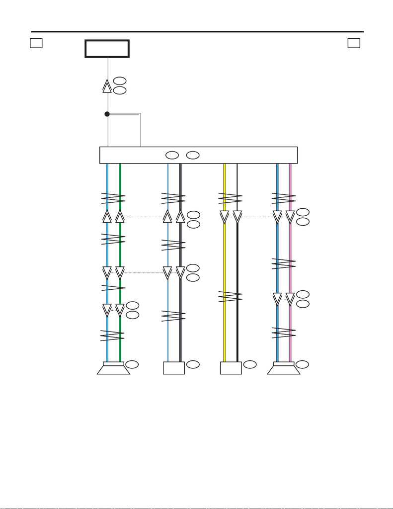

WI-305

Navigation System

WIRING SYSTEM

WI-44503

1c 1c

1

R316 R317

R1

B97

WB1

WB5

WW

B10

B4

L/W

G

L/W

G

C1Y

C2W/B

B3

B9

L

P

C3W/L

C9B/L

G

L/W

W/L

B/L

W/L

B/L

1

2 L/W

G

2

1Y

B

G

L/W

1

2L

PP

P

L

L

2

1 W/L

B/L

D2 i159

D84

i101

D12

D83

i76

i53

R98

i158

i102

R167

R82

R81

1

2

2

1

19

20

6

7

15

8

18

17

18

17

15

16

B: C:

FRONT DOOR

SPEAKER RH

SIDE

TWEETER RH

SIDE

TWEETER LH

MB-3

M/B FUSE NO. 5

(B)

AUDIO AMPLIFIER

FRONT DOOR

SPEAKER LH

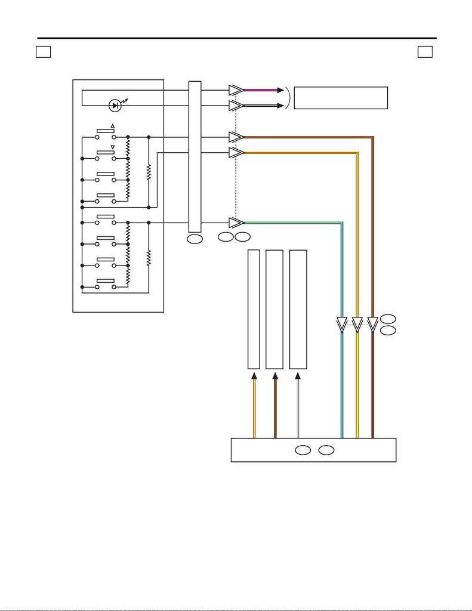

WI-306

Navigation System

WIRING SYSTEM

WI-44504

5

6

14

10

7

3

1

2

1d 1d

VOL +

VOL –

SEEK

SEEK

OFF HOOK

TALK

ON HOOK

MODE

ST3

B68ST1

V

Y/R

L/Y

B/W

BR

2

12

6

10

11

C21

C23 Y

BR/B

C22

BR/B

Y

L/Y L/Y

Y/R

BR

L/Y

C2

C3

D6

i231

B553

C:

i87

D:

i146

BR/Y

BR

GR

ROLL

CONNECTOR

REF. TO PARKING BRAKE /

BRAKE FLUID LEVEL WARNING LIGHT SYSTEM [a]

REF. TO CLEARANCE LIGHT &

ILLUMINATION LIGHT SYSTEM [1c] [2c]

REF. TO BACK-UP LIGHT SYSTEM [1a] [2a]

NAVIGATION UNIT

SATELLITE SWITCH

REF. TO CLEARANCE LIGHT &

ILLUMINATION LIGHT SYSTEM [1a] [2a]

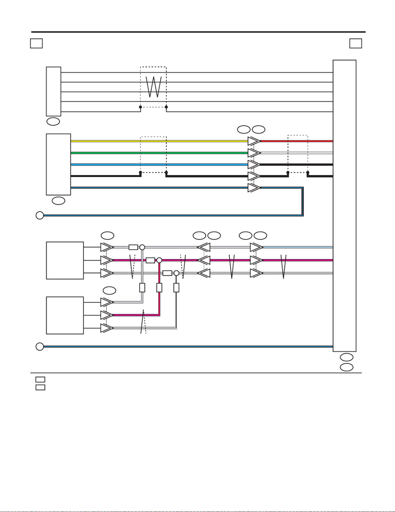

WI-307

Navigation System

WIRING SYSTEM

GR/L

V/R

W/B

B:

WI-44505

1e 1e

i87

C:

AD15

F:

1

OR

WR

12

13

11

5

6

4

17

18

19

B6

B4

B5

R50

B90

R56 B584 i238

B

OR

WR

WR

WR

OR

OR

GR

V/R

W/B

GR

V/R

W/B

GR

V/R

W/B

C19

C4

C5

V/R

GR/L

W/B

C6B/L

GR

V/R

W/B

B/L

GR

V/R

W/B

R62

4

1

2

3

5

R382

i195

R284

A

C26

C28

C27

C25

2

6

4

L

G

Y

1S

5 B/L

L

G

S

B/L

Y

B

W

R

S

B/L

B/L

B

W

S

R

1

1

F1

F3

F4

F2

2

4

3

1

AD16

: WITHOUT SUNROOF

: WITH SUNROOF

SPOT MAP LIGHT

(MICROPHONE)

SPOT MAP LIGHT

(MICROPHONE)

NAVIGATION

UNIT

AUX INPUT TERMINAL

AUX INPUT

TERMINAL (USB)

: SHIELD CONNECTOR

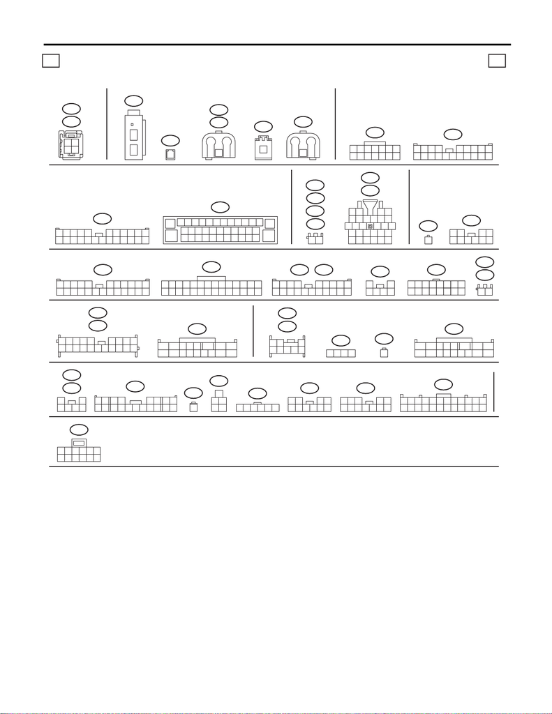

WI-308

Navigation System

WIRING SYSTEM

AD16

(GR)

AD15

(GR)

AN6

AN15

(GR)

AN1

(GR)

E:

F:

F:

AN2

1

(G)

2

13

1

ST3

2

1

89

5

12

6

7

34

1110

WI-44506

1f 1f

B68

3

42

156

7

13 1411

12

9

10

8

B310

23456789

1

10 11 12 13

14

15

26

16 17 18 19 20 21 22 23 24 25

27 28 29 30 31 32 33 34 35 36 37

38

D84

D83

19

18

20 21 22

1514131211

1

3

24

5

7

6

98

10

17

25

24

26 27 2823

16

12

D29

D23

D12

D2

i29

1

i50

12

34

56789

10

123456789

15 16 17 18 19 20 21 22 23 24

10 11 12 13 14

25 26 27 28

i87C:

A:

89

19 20

1234 567

10 11 12 13 14 15 16 17 18

i102 i238

i131B:

12

3456

i146D:

15

16

13

1411

12

9

10

78563412

12

i158

i159

R50

(GR)

10

13

345 6

14 15 16 17

1211

12 78

9

i230

(GR)

10

13

345 6

14 15 16 17

1211

12 78

9

i231

i195

12345 6789

10 11 12 13 14 15 16 17 18 19 20

(B)

R82

1

9

234 5678

10 11 12 14 15 16 17 18 1913

R13

R10

65

21

4

3

87

R97

1

R284

123456

3412 89

10 11

12 13 14 15 16 17 18 19 20 21 22 23 24

567

B99

R386

A:

123456789101112

13 14 15 16 17 18 19 20 21 22 23 24

1234

R14

R117

12

34

R316

B:

12

34

56789

10

R317

C:

123 45

6 7 8 9 10 11 12

3412 89

10 11

12 13 14 15 16 17 18 19 20 21 22 23 24

567

i53

R62B:

R56

5634

21

R17

(B)

1

AN5

AN7

2

13

12

34

1

2

89

19 20

1234 567

10 11 12 13 14 15 16 17 18

B97

LIST OF CONNECTORS

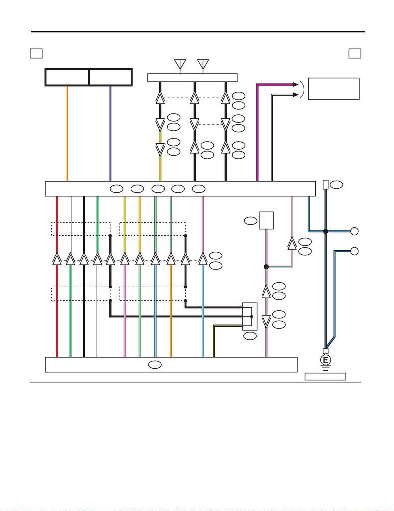

WI-309

Navigation System

WIRING SYSTEM

2. ENGINE TYPE EJ

WI-45443

i131B

2a 2a

i50A

R386A

30A11 P/G P/G P/G

Y/R

L/R

Y/R

L/RA4

A3

V

V

A10

B/W

B/W

B5

B310

C:

i87

E:

AN1

F:

AN2

i29

B/L

B/L A7

1

B/L

A

B/L

B

C17

P/G

B/L

B/L

1

P/G

VDC CM

:

::

R14

J/C

1

1

1

A5

A4

A3

A2

A23

A22

A18

A17

A12

RA1

WA5

BA2

G

S

S

S

S

A6

Y/B B1

Y/R B3

LG B2

LG/B B6

P

R

G

B

W

P

LG

SB

O

SB

A6 B/Y

B/Y

S

S

A9

20

8

9

7

19

18

11

6

10

13

12

i195

R382

11

i230

23

R3

B99

R81

R82

19

AN15

AN11

AN6

AN4

AN5

AN3

AN8

R97

R167

i102

AN9

AN7

2

3

1

3

112

3

1

1

B552

Y/B

B

B

A8

E2

F1

B

B

B

B

B

B

Y/B

B

B

: TERMINAL No. OPTIONAL ARRANGEMENT

AUDIO AMPLIFIER

NAVIGATION UNIT

REF. TO GND [e]

FB-25

F/B FUSE NO. 24

(ACC)

FB-10

M/B FUSE NO. 8

(B)

REF. TO CLEARANCE

LIGHT & ILLUMINATION

LIGHT SYSTEM [1d] [2d]

AUDIO

BRACKET

GROUND

ANTENNA

SATELLITE

ANTENNA

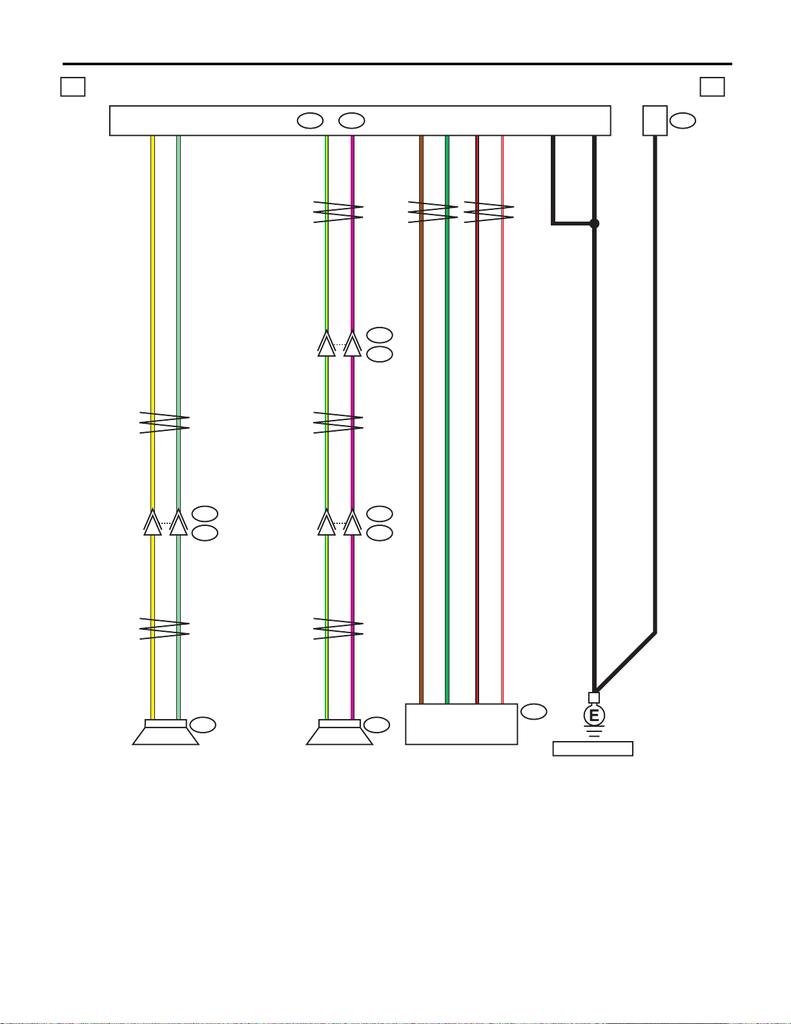

WI-310

Navigation System

WIRING SYSTEM

WI-45444

D23

2b 2b

D29

5

6

5

6

R317 R17C

B2

B61

2

G/Y

V

C5

C12

B

B

B

C6

C7

BB

1

BR

G

B8

B71

2

Y

LG

Y

LG

G/Y

V

G/Y

V

BR

G

C4

C10

3

4

1

2

B/R

W/R

B/R

W/R

Y

LG

G/Y

V

Y

LG

D28

R13

D22

R10

13

14

R81

R82

:R316B:

R117

REAR DOOR

SPEAKER RH (LOW)

REAR DOOR

SPEAKER LH (LOW)

AUDIO AMPLIFIER

AMPLIFIER

BRACKET GROUND

REF. TO GND [g]

WOOFER

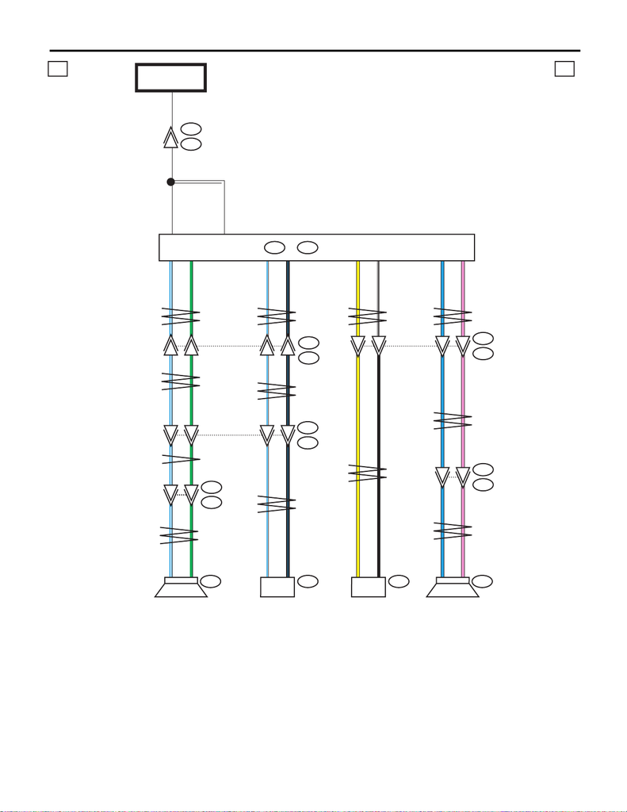

WI-311

Navigation System

WIRING SYSTEM

WI-45445

2c 2c

1

R316 R317

R1

B97

WB1

WB5

WW

B10

B4

L/W

G

L/W

G

C1Y

C2W/B

B3

B9

L

P

C3W/L

C9B/L

G

L/W

W/L

B/L

W/L

B/L

1

2 L/W

G

2

1Y

B

G

L/W

1

2L

PP

P

L

L

2

1 W/L

B/L

D2 i159

D84

i101

D12

D83

i76

i53

R98

i158

i102

R167

R82

R81

1

2

2

1

19

20

6

7

15

8

18

17

18

17

15

16

B: C:

FRONT DOOR

SPEAKER RH

SIDE

TWEETER RH

SIDE

TWEETER LH

MB-3

M/B FUSE NO. 5

(B)

AUDIO AMPLIFIER

FRONT DOOR

SPEAKER LH

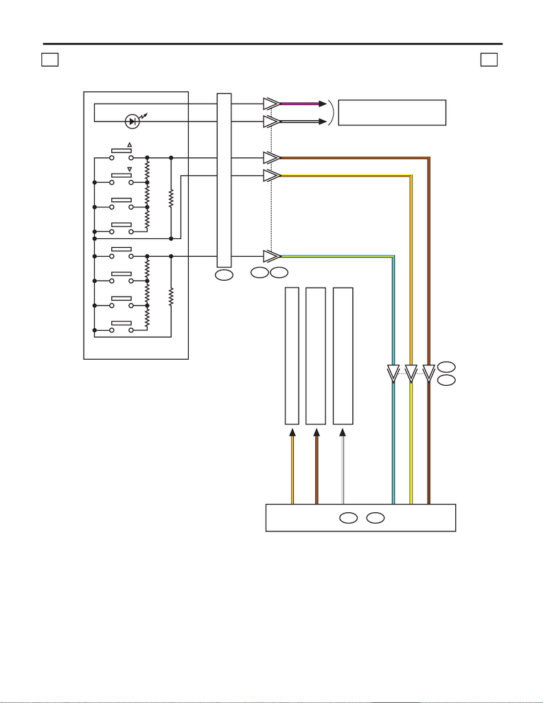

WI-312

Navigation System

WIRING SYSTEM

WI-45446

5

6

14

10

7

3

1

2

2d 2d

VOL +

VOL –

SEEK

SEEK

OFF HOOK

TALK

ON HOOK

MODE

ST3

B68ST1

V

Y/R

L/Y

B/W

BR

2

12

6

10

11

C21

C23 Y

BR/B

C22

BR/B

Y

L/Y L/Y

Y/R

BR

L/Y

C2

C3

D6

i231

B553

C:

i87

D:

i146

BR/Y

BR

GR

ROLL

CONNECTOR

REF. TO PARKING BRAKE /

BRAKE FLUID LEVEL WARNING LIGHT SYSTEM [a]

REF. TO CLEARANCE LIGHT &

ILLUMINATION LIGHT SYSTEM [1c] [2c]

REF. TO BACK-UP LIGHT SYSTEM [1a] [2a]

NAVIGATION UNIT

SATELLITE SWITCH

REF. TO CLEARANCE LIGHT &

ILLUMINATION LIGHT SYSTEM [1a] [2a]

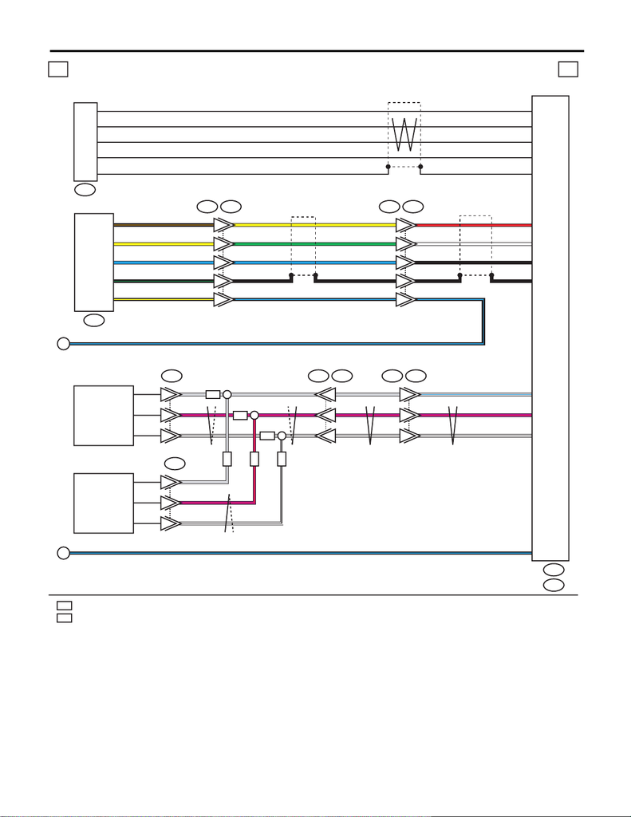

WI-313

Navigation System

WIRING SYSTEM

WI-45447

2e 2e

i87

C:

1

1

F1

F3

F4

F2

2

4

3

1

AD16

10

8

12

9

11

L

G

S

B/L

Y

Y

B/G

B/O

L

B/Y

GR

V/R

W/B

GR

V/R

W/B

GR

V/R

W/B

V/R

GR/L

W/B

GR/L

V/R

W/B

GR

V/R

W/B

GR

V/R

W/B

C19

C4

C5

C6B/LB/L

AD15

F:

B

OR

WR

1

17

18

19

OR

WR

WR

WR

OR

OR

5

6

4

B6

B4

B5

R56

R62

B:

C26

C28

C27

C25

6

1

4

2

5

G

S

Y

L

B/L

B

W

R

S

B/L

B

W

S

R

AD7

AD6

R34

R382

i195

R50

B90

B584 i238

12

13

11

4

1

2

3

5

B/L

A

: WITHOUT SUNROOF

: WITH SUNROOF

STEREO CAMERA

COVER

(MICROPHONE)

OVERHEAD

CONSOLE

(HANDSFREE

MICROPHONE)

NAVIGATION

UNIT

AUX INPUT TERMINAL

AUX INPUT

TERMINAL (USB)

: SHIELD CONNECTOR

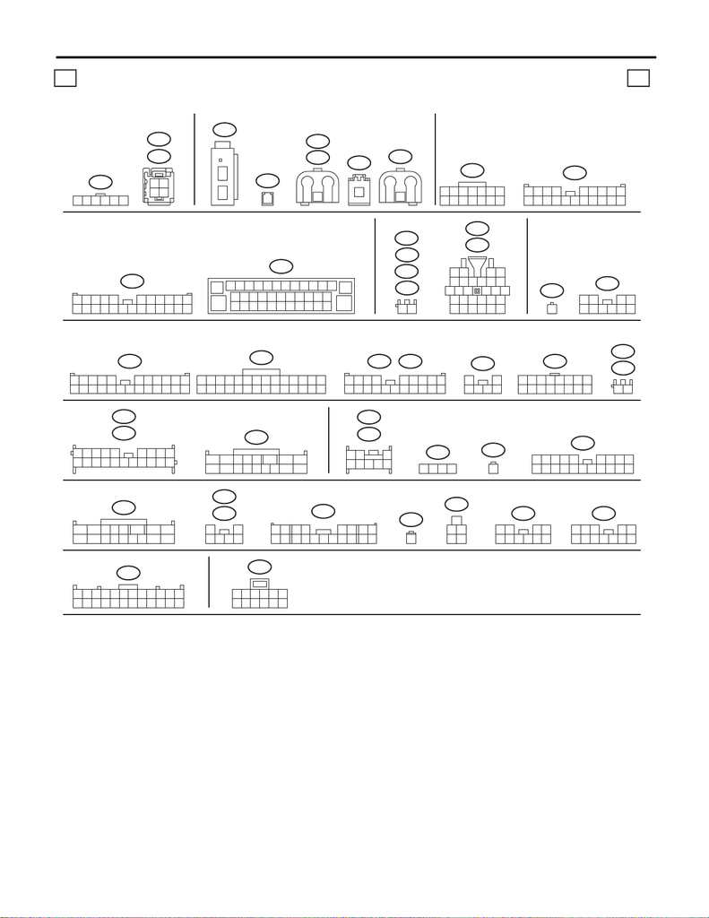

WI-314

Navigation System

WIRING SYSTEM

AD7

123456

AN6

AN15

(GR)

F:

AN2

1

(G)

2

13

1

ST3

2

1

89

5

12

6

7

34

1110

WI-45448

2f 2f

B68

3

42

156

7

13 1411

12

9

10

8

B310

23456789

1

10 11 12 13

14

15

26

16 17 18 19 20 21 22 23 24 25

27 28 29 30 31 32 33 34 35 36 37

38

D84

D83

19

18

20 21 22

1514131211

1

3

24

5

7

6

98

10

17

25

24

26 27 2823

16

12

D29

D23

D12

D2

i29

1

i50

12

34

56789

10

123456789

15 16 17 18 19 20 21 22 23 24

10 11 12 13 14

25 26 27 28

i87C:

A:

89

19 20

1234 567

10 11 12 13 14 15 16 17 18

i102 i238

i131B:

12

3456

i146D:

15

16

13

1411

12

9

10

78563412

12

i158

i159

R50

(GR)

10

13

345 6

14 15 16 17

1211

12 78

9

i230

(GR)

10

13

345 6

14 15 16 17

1211

12 78

9

i231

i195

12345 6789

10 11 12 13 14 15 16 17 18 19 20

(B)

R82

1

9

234 5678

10 11 12 14 15 16 17 18 1913

R13

R10

65

21

4

3

87

R97

1

3412 89

10 11

12 13 14 15 16 17 18 19 20 21 22 23 24

567

B99

R386

A:

123456789101112

13 14 15 16 17 18 19 20 21 22 23 24

1234

R14

R117

12

34

R316

B:

12

34

56789

10

R317

C:

123 45

6 7 8 9 10 11 12

3412 89

10 11

12 13 14 15 16 17 18 19 20 21 22 23 24

567

i53

R62B:

R56

5634

21

R34

123

161514

546789

17 18 19 2013121110

R17

1

AN5

AN7

2

13

AN1

(GR)

E:

1

2

(GR)

AD16

F:

(GR)

AD15

12

34

LIST OF CONNECTORS

89

19 20

1234 567

10 11 12 13 14 15 16 17 18

B97